# inClass-03/13/2018

```r
library(ISLR)
library(leaps)
```

## Subset Selection

### Best Subset

If we have a data set with $p$ predictors, the total number of possible linear models we could attempt is $2^p$. Why is that?

With Best Subset selection, we do a brute-force search and evaluate all $2^p$ models and look for the best one (see Figure 6.1 in the book). Why is it important that we only make comparisons between models that have the same number of predictors? Why can we just choose the best model from the set of the $2^p$ models we evaluated?

*Exercise* Try Best Subset with the Hitters data using the regsubsets function in the leaps package.

### Forward Stepwise

For computational savings, we can turn to Forward Stepwise which doesn’t compute $2^p$ models but a much smaller set. Forward Stepwise proceeds through greedy search. How does Forward Stepwise proceed? What are the limitations?

**Exercise** Try Forward Stepwise with the Hitters data.

## Model Comparison Metrics

All of the following metrics are based on the idea of trading off a model’s goodness-of-fit with the model’s flexibility. That is, they are all a quantification of how we should *penalize* models with more parameters. Their only major differences are how they quantify this penalty.

The following formula apply specifically to the case of linear regression. Therefore, the goodness-of-fit metric is the RSS. But these metrics have a more generic form which can be applied to any statistical model, and where the goodness-of-fit is quantified by the maxkimum of the Likelihood ($\hat{L}$).

### Mallow’s C

$$C_p = \frac{1}{n}(RSS + 2d\hat{\sigma}^2)$$

### Akaike Information Criterion

$$AIC = \frac{1}{n \hat{\sigma}^2}(RSS + 2d\hat{\sigma}^2)$$
or more generally

$$AIC = 2d - 2ln(\hat{L})$$

### Bayesian Information Criterion

$$BIC = \frac{1}{n \hat{\sigma}^2}(RSS + log(n)d\hat{\sigma}^2)$$

or more generally

$$BIC = ln(n)d - 2ln(\hat{L})$$

### Adjusted R Squared

$$Adj R^2 = 1 - \frac{RSS/(n-d-1)}{TSS/(n-1)}$$

```r
full_subsets = regsubsets(Salary ~ ., data=Hitters, nvmax = 19, method= c("forward"))
full_subsets_summary = summary(full_subsets)
full_subsets_summary
names(full_subsets_summary)
```

[output not shown]

Make a few plots showing BIC, and Mallow’s C, and 1-AdjustedRsquared. Are the different metrics in rough agreement?

Question: These metrics are evaluted with the full training set. Another way we can approach the problem of model selection is to use cross validation. What are the pros and cons of each approach?

# Regularized Regression

With multiple linear regression, our loss function was the Residual Sum of Squares

$$\begin{align}
L = RSS =& \sum_i (\hat{y_i} - y_i)^2 \\
&= \sum_i (\left( \beta_0 + \beta_1 X_1 + .... \right) - y_i)^2
\end{align}$$

With this is mind, we could cast the problem of statistical inference as merely a problem of optimization: we want to find the vaulues of $\beta_0, \beta_1,...$ which lead to the *minimum* value of RSS.

$$\hat{\beta} = \min_{\beta} RSS \\
\hat{\beta} = \min_{\beta} \sum_i (\left( \beta_0 + \beta_1 X_1 + .... \right) - y_i)^2$$

Then $\hat{\beta}$ is our *best* estimate of the “right” values of the model coefficients.

However, there are a few regimes where this model will fail and we need to come up with a more general form that allows us to make an accomodation. For example, if the number of predictors is very large, many of the predictors might be uncorelated with Y, and we just end up overfitting the training data. Worse still, if the number of predictors is larger than the number of datapoint, then the Linear Regression problem has no solution. To prevent this kind of overfitting, we will turn to *Regularized Regression* (also known as Penalized Regression).

We change our Loss function

$$L = \sum_i (\left( \beta_0 + \beta_1 X_1 + .... \right) - y_i)^2 + g(\beta) \\
L = f(X, \beta) + g(\beta) \\
L = f(X, \beta) + \lambda g(\beta) \\$$

Most commonly, we’ll still use the RSS as part of our loss function.

$$L = RSS + \lambda g(\beta)$$

The interesting differenc is that we now add a new term to the loss function and this term only depends on the values of the coefficients $\beta$. That function can take many forms and we scale it by a scalar factor $\lambda$. The net effect of this is that values of $\beta$ which have large magnitude will be *penalized* due to the presence of this new term.

Now, when we solve this optimization problem, the $\hat{\beta}$ we find is not just dependent on minimizing RSS. Instead, we’ll see that we need to tradeoff minimizing RSS under the constraints implied by the function $g(\beta)$. Large values of $\beta$ tend to be penalized, so that $\hat{\beta}$ will tend to reveal smaller overall magnitudes of the parameters. For this reason, these techniques are often reffered to as *shrinkage*.

## Ridge Regression

With Ridge Regression, our penalty function on $\beta$ is the L2-norm, or Euclidean magnitude.

$$g(\beta) = \Vert \beta \Vert _2 = \sum_j \beta_j ^2$$

## LASSO

With LASSO Regression, our penalty function on $\beta$ is the L1-norm, similar to the absolute value.

$$g(\beta) = \Vert \beta \Vert _1 = \sum_j \lvert \beta_j \rvert$$

## Constrained Optimization Concepts

Create some fake data and plot it.

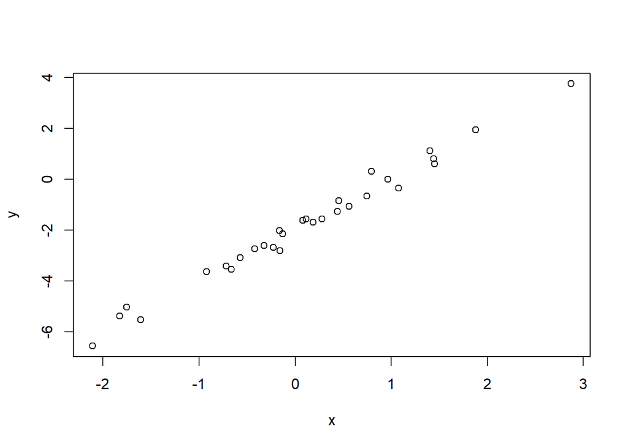

Now, we want to fit a simple linear regression model to this data. Recall that we’re trying to find the combination of $\beta_0$ and $\beta_1$ that yields the lowest RSS. Let’s visualize this RSS surface. I’ll also highlight the “true” value of the coefficients.

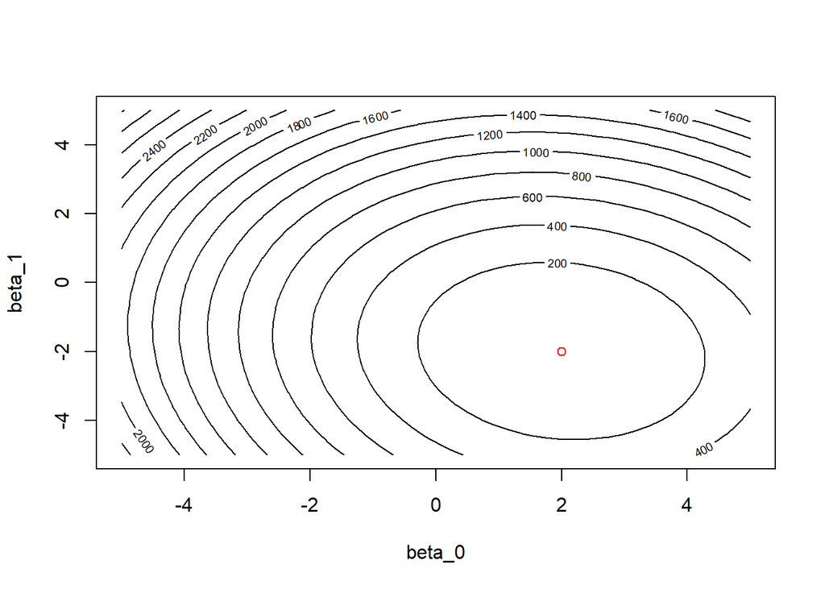

```r
beta_0_range = seq(-5,5,length.out=50)
beta_1_range = seq(-5,5,length.out=50)

calc_SSE <- function(parameters, x, y) {
  y_hat <-parameters[1] + parameters[2]*x
  sum((y_hat - y)^2)
}

beta_space <- expand.grid(beta_0_range, beta_1_range)
beta_space$SSE <- apply(beta_space[,c("Var1","Var2")], 1, function(p){ calc_SSE(p,x, y) })

contour(x=beta_0_range, y=beta_1_range, z= matrix(beta_space$SSE, nrow=50, byrow=TRUE),nlevels=20, xlab="beta_0", ylab="beta_1" )
points(2,-2,col="red")
```

I have highlighted in red the likely minimum of this paraboloid, the point $\beta_0=2 \beta_2=-2$. This is the global minimum over the whole parameter space. But I can also ask what the minimum of the paraboloid would be subect to some constraint. For example, what if I say that $\beta_1$ must be constrained to be equal to 2. What does this imply about our minimization problem?

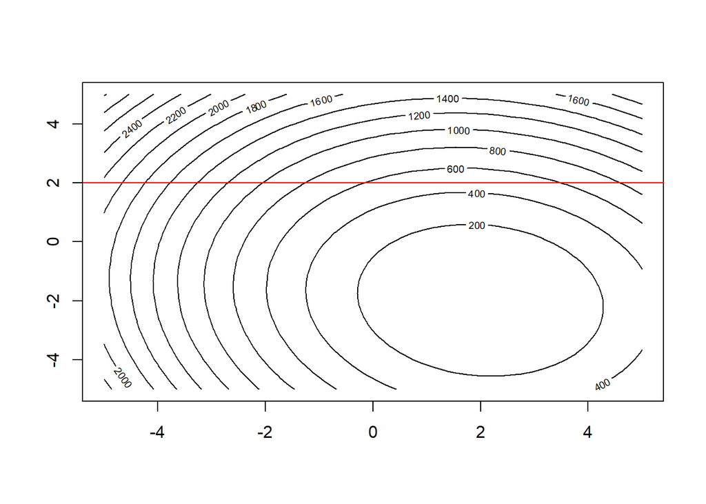

This plot shows the line $\beta_1=2$ and this is the constraint that we must adhere to. So our answer about the “minimum” must be the minimum of the paraboloid that lies on this line. Said differently, imagine that this line “slices” through the paraboloid and yields a parabola of which we simpy find the minimum. So our new minimum (under the constraint) is a little bit different than the “true” minimum.

Similarly, we can have a different constraint, maybe $\beta_0$ must be 1.

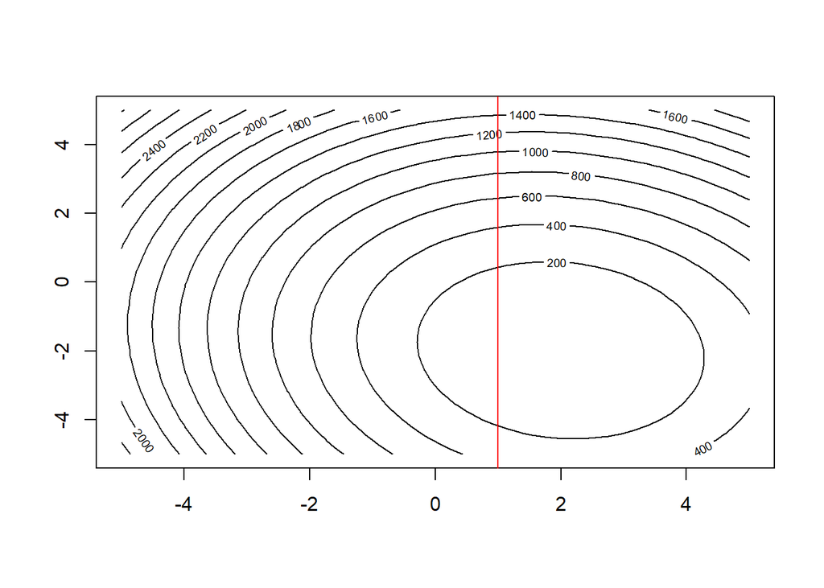

Aside from simple equality constraints, we can have constraint regions. So our constraint might be that $\beta_0$ must be greater than or equal to -2. So any value of $\beta_0$ large than -2 is permissible. In this case (any in many cases), the constraint region is optimized at the boundary of the constraint, so the line x=-2 is still the relevant constraint. And we can also have linear and non-linear constraints boundaries, and that’s what Lasso and Ridge Regression are all about.

### Ridge

Let’s look again at the loss function for Ridge Regression.

$$L = \sum_i (y_i - \hat{y_i})^2 + \lambda \sqrt{\sum_j \beta_j ^2}$$

For any given value of the penalization parameter $\lambda$, we can recast our Loss function as with the form of a constraint.

$$\begin{aligned}
L = \sum_i (y_i - (\beta_0 + \beta_1 x_i))^2 \\
\textrm{subject to } \beta_0^2 + \beta_1^2 \le s^2
\end{aligned}$$

which is a circular region in our two dimensional parameter space and is a hyper-sphere most generally.

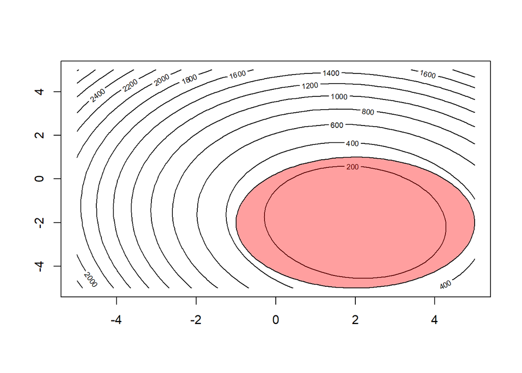

### Lasso

Let’s look again at the loss function for Lasso Regression.

$$L = \sum_i (y_i - \hat{y_i})^2 + \lambda \sum_j |\beta_j|$$

For any given value of the penalization parameter $\lambda$, we can recast our Loss function as with the form of a constraint.
$$\begin{aligned}
L = \sum_i (y_i - (\beta_0 + \beta_1 x_i))^2 \\
\textrm{subject to } |\beta_0| + |\beta_1| \le s
\end{aligned}$$

That constraint $|\beta_0| + |\beta_1| \le s$ defines a region in the $\beta_0, \beta_1$ parameter space. In two dimensions this region is “diamond” shaped and in higher dimensions is referred to as an “L-1 Ball” but is a pointy shape nonetheless.

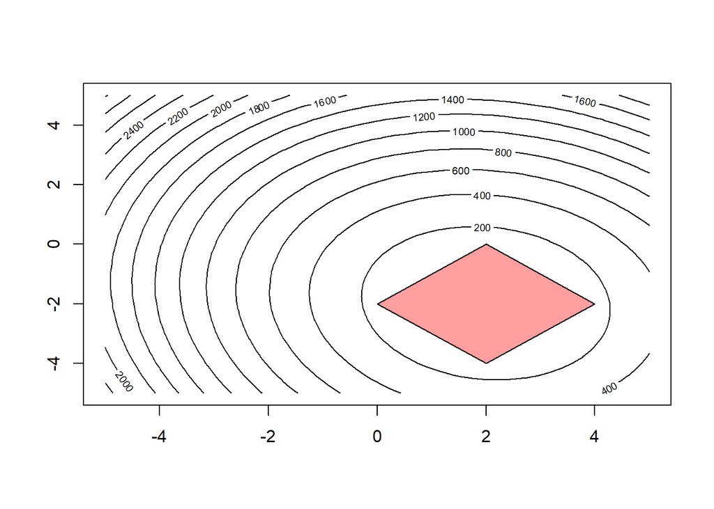

### Why Do All This?

These constraint regions enforce that our estimates of $\hat{\beta}$ will lie within some bounded area near zero. This prevents any of the coefficients from being too large and thus helps prevent overfitting and improves model variance.

As we increase the value of the penalty $\lambda$, we make our constraint region tighter and tighter. Consider the extreme cases here. If $\lambda$ is very small (very little penalization), then our constraint region is very large and it probably contains the true minimum RSS. So our estimate of $\hat{\beta}$ in this instance will be the same as with unconstrained regression. As we increase $\lambda$, the constraint region pulls in toward the origin, thus making our estimate of $\hat{\beta}$ different than the one for just RSS. As $\lambda$ is increased further, our parameters shrink closer and closer to the origin.

The important difference betwee Lasso and Ridge Regression is what happens as we increase $\lambda$. For Ridge, as we increase $\lambda$, our coefficients smoothly shrink in magnitude as they stay within the constraint region. The coeffcients can change sign, but it’s unlikely that they’re every exactly 0.

In contrast, because of the L-1 Ball constraint region of Lasso, as we increase $\lambda$ (shrink the constraint region), it is highly likely that the our best estimate of $\vec{\beta}$ hits one of the “corners” of the L-1 Ball, where it then gets stuck. What this means is that a subset of the corresponding features are given a coefficient of exactly zero, thus taking them out of the model. We’ll explore these ideas in the next section, but the takeaway is that Lasso performs “feature selection” for us - telling us which features can be dropped from the model for any given level of $\lambda$.

### Regularized Regression Trajectories

Aside from thinking about $\lambda$ as defining a constraint region, we can examine the full range of $\lambda$ and examine the impact on the optimal $\hat{\beta}$. Think about the extreme cases here:

**Questions** 1. When $\lambda = \inf$, what is the value of $\hat{\beta}$? 1. When $\lambda = 0$, what is the value of $\hat{\beta}$ and how does it relate to $\hat{\beta}$ of regular regression?

Take a look with a real dataset.

```r
library("glmnet")
library("ISLR")


head(Hitters)
```

```
##                   AtBat Hits HmRun Runs RBI Walks Years CAtBat CHits
## -Andy Allanson      293   66     1   30  29    14     1    293    66
## -Alan Ashby         315   81     7   24  38    39    14   3449   835
## -Alvin Davis        479  130    18   66  72    76     3   1624   457
## -Andre Dawson       496  141    20   65  78    37    11   5628  1575
## -Andres Galarraga   321   87    10   39  42    30     2    396   101
## -Alfredo Griffin    594  169     4   74  51    35    11   4408  1133
##                   CHmRun CRuns CRBI CWalks League Division PutOuts Assists
## -Andy Allanson         1    30   29     14      A        E     446      33
## -Alan Ashby           69   321  414    375      N        W     632      43
## -Alvin Davis          63   224  266    263      A        W     880      82
## -Andre Dawson        225   828  838    354      N        E     200      11
## -Andres Galarraga     12    48   46     33      N        E     805      40
## -Alfredo Griffin      19   501  336    194      A        W     282     421
##                   Errors Salary NewLeague
## -Andy Allanson        20     NA         A
## -Alan Ashby           10  475.0         N
## -Alvin Davis          14  480.0         A
## -Andre Dawson          3  500.0         N
## -Andres Galarraga      4   91.5         N
## -Alfredo Griffin      25  750.0         A
```

```r
# Make a model matrix as in the R lab video.
X.model = model.matrix(Salary ~ .-1, data = Hitters)
head(X.model)
```

```
##                   AtBat Hits HmRun Runs RBI Walks Years CAtBat CHits
## -Alan Ashby         315   81     7   24  38    39    14   3449   835
## -Alvin Davis        479  130    18   66  72    76     3   1624   457
## -Andre Dawson       496  141    20   65  78    37    11   5628  1575
## -Andres Galarraga   321   87    10   39  42    30     2    396   101
## -Alfredo Griffin    594  169     4   74  51    35    11   4408  1133
## -Al Newman          185   37     1   23   8    21     2    214    42
##                   CHmRun CRuns CRBI CWalks LeagueA LeagueN DivisionW
## -Alan Ashby           69   321  414    375       0       1         1
## -Alvin Davis          63   224  266    263       1       0         1
## -Andre Dawson        225   828  838    354       0       1         0
## -Andres Galarraga     12    48   46     33       0       1         0
## -Alfredo Griffin      19   501  336    194       1       0         1
## -Al Newman             1    30    9     24       0       1         0
##                   PutOuts Assists Errors NewLeagueN
## -Alan Ashby           632      43     10          1
## -Alvin Davis          880      82     14          0
## -Andre Dawson         200      11      3          1
## -Andres Galarraga     805      40      4          1
## -Alfredo Griffin      282     421     25          0
## -Al Newman             76     127      7          0
```

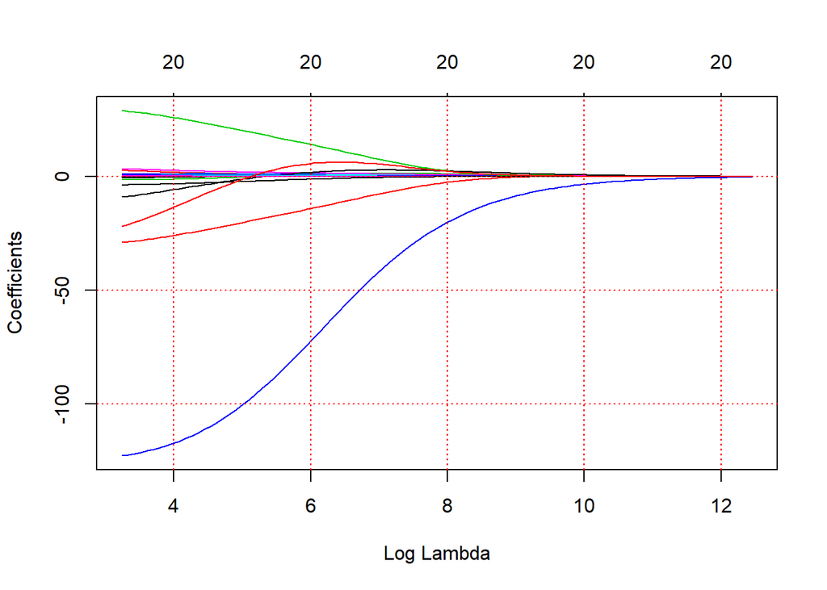

```r
y = Hitters$Salary

# remove the NAs:
y <-na.omit(y)

# Make a sequence of ridge regression models and plot:
fit.ridge = glmnet(X.model, y, alpha = 0)
plot(fit.ridge, xvar = "lambda")
grid(col = 2)
```

**Question**: What is this trajectory plot is telling us?

### Exercise

1. Divide entries in the first two columns by 10. Redo the fit and the plot. Do any of the curves change substantially?

It is wise to standardize the model features (so that the sum of squares of all columns now are 1).

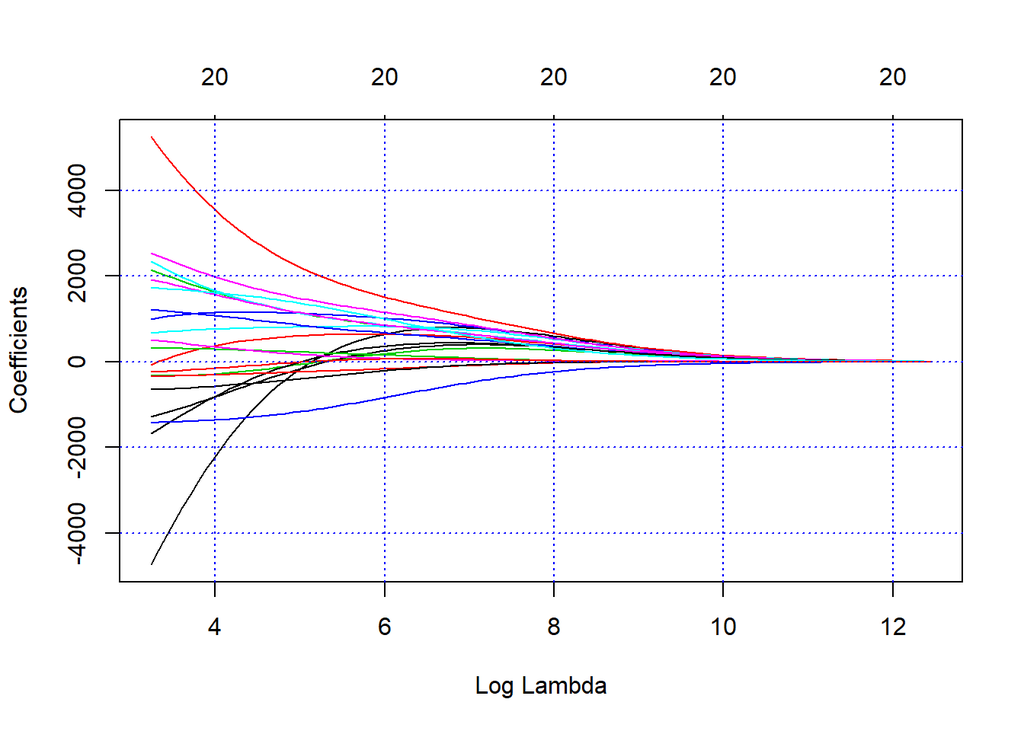

```r
for (j in 1:20){X.model[,j] <- X.model[,j]/sqrt(sum(X.model[,j]^2))}
fit.ridge3 = glmnet(X.model, y, alpha = 0)
plot(fit.ridge3, xvar = "lambda")
grid(col = 4)
```

Now that all the features have similar magnitudes, there are more coefficients in the trajectory plot that have similar magnitudes.

#### Now LASSO

Now explore the lasso. Let’s use the same model matrix, the standardized one we just created.

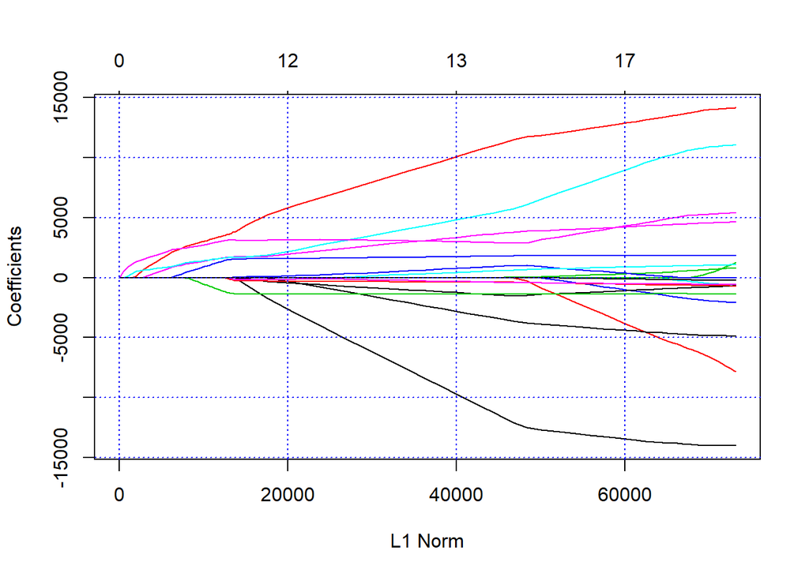

```r
fit.lasso = glmnet(X.model, y, alpha = 1)
plot(fit.lasso)
grid(col = 4)
```

This is a plot of the coefficient magnituges against the L1 norm of the coefficients (the sum of absolute values). If this is large, this means lambda must be small. The right side of the plot corresponds to the case with is no lambda. The left side of the plot corresponds to where lambda is as large as it gets.

You can also make a LASSO plot against the value of $\lambda$ which can be a little easier to talk about.

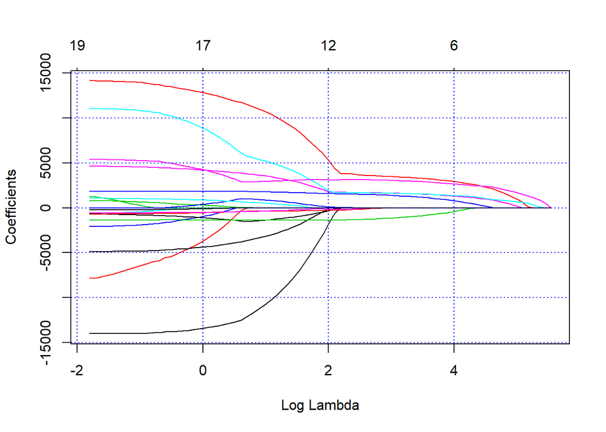

```r
plot(fit.lasso,xvar = "lambda")
grid(col = 4)
```

**Questions**

1. Which side of this plot corresponds to large values of $\lambda$? Which side of this plot corresponds to small values of $\lambda$? Which side of this plot corresponds most closely to regular regression?
2. At a value of $log \lambda = 1$, how many features have been removed from the model?
3. At a value of $log \lambda = 3$, how many features remain in the model?
4. In what way does LASSO help us with the problem of feature selection? Does Ridge Regression also help in that way?

### Cross Validation

So how do we choose the right value of lambda? As is becoming a common theme in this course, we’ll use Cross Validation. And the glmnet package makes this very easy for us.

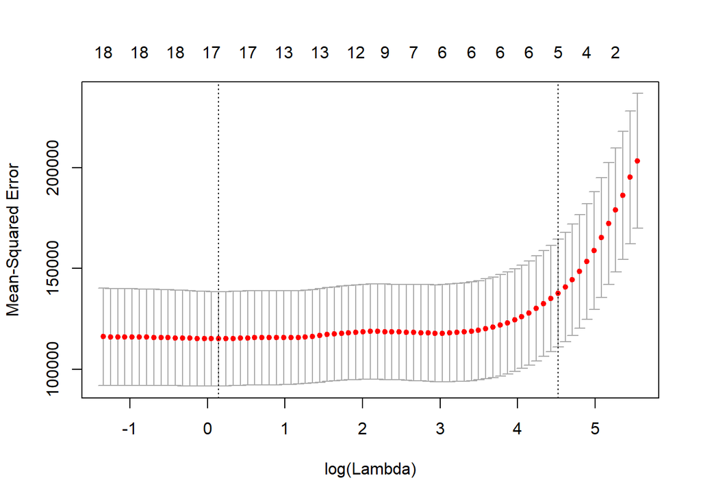

```r
cv.lasso = cv.glmnet(X.model,y,alpha = 1)
plot(cv.lasso)
```

#### Coefficient Outputs

Notice the outputs of the fit is a matrix called beta: this has nrow equal to the total number of features in the model, and ncol equal to the number of different values of lambda that were computed.

**Question**

What does this matrix represent? How can we use it?

**Exercise**

Cross validation told us that a value of log-lambda of 3 is a pretty good bet. Extract the model coefficients that correspond to log-lambda of (approximately) 3. Recall, there should only be 6 non-zero coefficients.

#### Predictions

The predict function for these “glmnet” objects will allow us to specify which value of lambda we want. By default, this function return predictions for the full range of $\lambda$ but you can also specify a single value.

```r
lasso_prediction_full <- predict(fit.lasso, X.model[1:2,])

lasso_prediction_best <- predict(fit.lasso, X.model[1:2,], s=fit.lasso$lambda[29])
```